# R Notebook

Load in the libraries you need, and look at the backpack data. Take note of variable names and dimensions.

```r
library(tidyverse)
library(CodeClanData)
library(scales)

backpack <- backpack
```

What is the distribution of backpack weights that students are carrying? Choose an appropriate graph to show the distribution.

```r
count_data <- backpack %>%
  group_by(backpack_weight, sex) %>%
  summarise(counts = n())
```

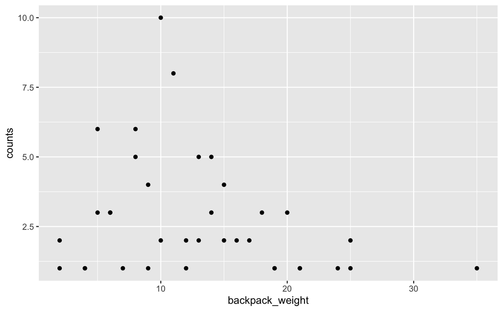

```r
ggplot(count_data) +
  aes(backpack_weight, counts) +
  geom_point()
```

This plot shows us that most of the backpacks weigh 10(kg?) or around that mark

Are there differences in backpack weight between sex?

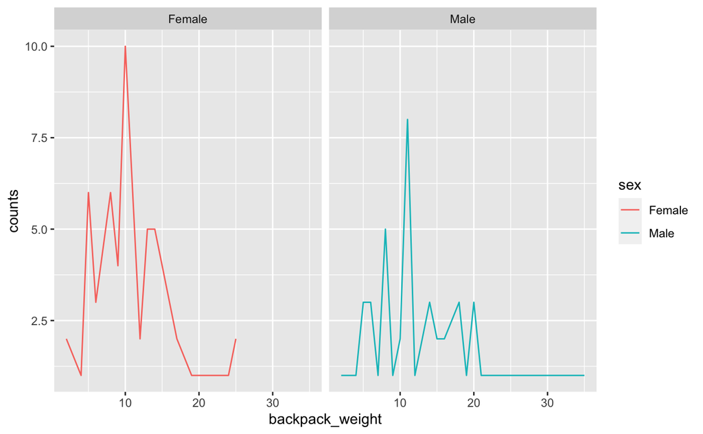

```r
ggplot(count_data) +
  aes(backpack_weight, counts, colour = sex) +
  geom_line() +
  facet_wrap(~ sex)
```

The plot shows that females tend to have lighter backpacks more frequently than males.

What is the relationship between body weight and backpack weight?

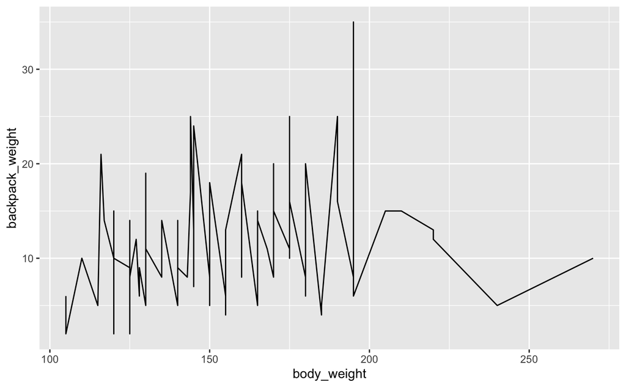

```r
ggplot(backpack) +
  aes(body_weight, backpack_weight) +
  geom_line()
```

As body weight increases, the weight of the backpack goes up, until body weight reaches about 200 then backpack weight drops substantially.

Is this relationship different between men and women? Choose an appropriate plot and interpret your findings.

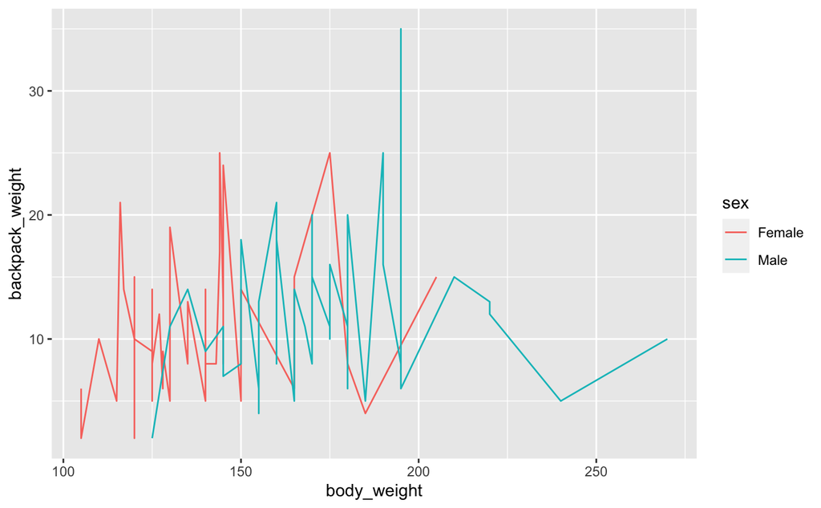

```r
ggplot(backpack) +
  aes(body_weight, backpack_weight, colour = sex) +
  geom_line()
```

The trend of back pack weight rising as body weight increasing is also seen in woman but back pack weight seems to peak at around 175 pounds and decreases for women.